# IA2

Jake VanCampen

November-18-2017

```r
knitr::opts_chunk$set(warning = FALSE, message = FALSE)
```

## Exploratory Data Analysis

A dataset concerned with thte effects of two fixed factors (genotype, and water) on the levels of three different proteins (ERD10, NCED9 and SRK2D) in Arabidopsis root tissues was explored to determine test the hypothesis that proteins in the root tissues are affected by genotype and water.

First the data were read into R:

```r
library(tidyverse)
plant_data <- read_tsv('Plant_stress-1.tsv')
head(plant_data)
```

```
## # A tibble: 6 x 6
##   Individual Genotype  Water ERD10 NCED9 SRK2D
##        <chr>    <chr>  <chr> <int> <int> <int>
## 1        AC1   mutant stress   937    77  1431
## 2        AC2   mutant stress   974    55  1332
## 3        AC3   mutant stress  1202    23  3909
## 4        AC4   mutant stress  1048    49  3193
## 5        AC5   mutant stress   982     2  3491
## 6        AC6   mutant stress   729    16  2670
```

The two factors Genotype and Water should be cooerced to factors:

```r
plant_data$Genotype <- factor(plant_data$Genotype)
plant_data$Water <- factor(plant_data$Water)
head(plant_data)
```

```
## # A tibble: 6 x 6
##   Individual Genotype  Water ERD10 NCED9 SRK2D
##        <chr>   <fctr> <fctr> <int> <int> <int>
## 1        AC1   mutant stress   937    77  1431
## 2        AC2   mutant stress   974    55  1332
## 3        AC3   mutant stress  1202    23  3909
## 4        AC4   mutant stress  1048    49  3193
## 5        AC5   mutant stress   982     2  3491
## 6        AC6   mutant stress   729    16  2670
```

The effect of the two factors can be evaluated using boxplots for each protein in question:

### ERD10

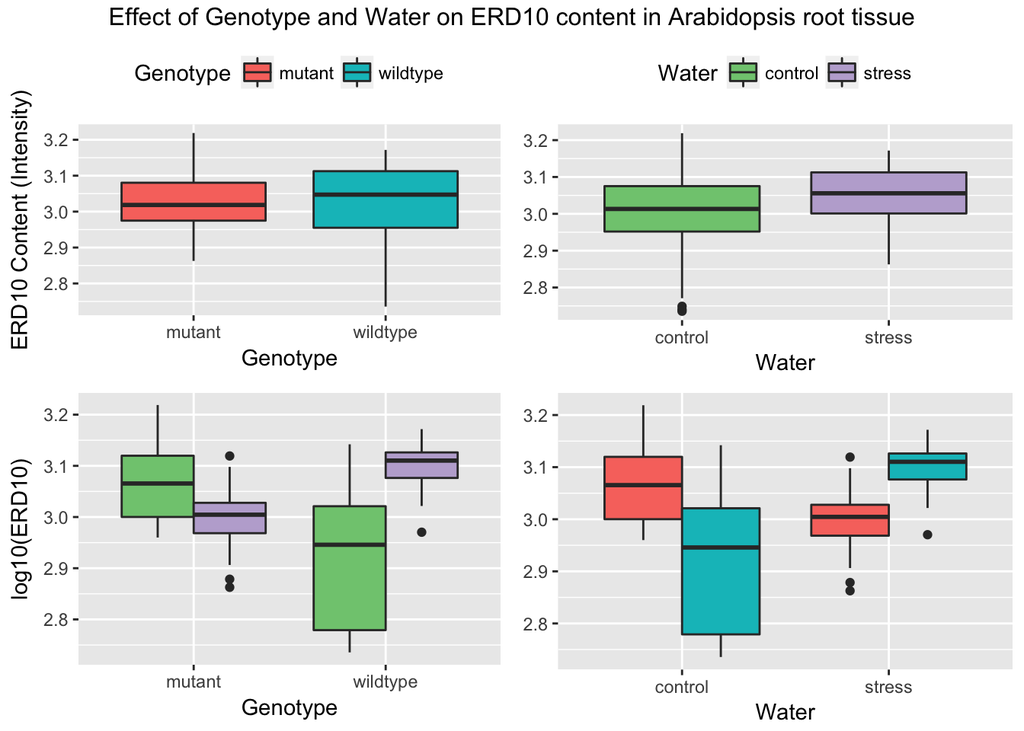

```r
library(ggpubr)

wERD10 <- ggplot(plant_data)+
  geom_boxplot(aes(Genotype, log10(ERD10), fill = Genotype)) +
  ylab('ERD10 Content (Intensity)')+
  theme(legend.position = 'top')

gERD10 <- ggplot(plant_data)+
  geom_boxplot(aes(Water, log10(ERD10), fill = Water))+
  theme(legend.position = 'top', axis.title.y = element_blank())+
  scale_fill_brewer(palette = 'Accent')

iERD10 <- ggplot(plant_data)+
  geom_boxplot(aes(Genotype, log10(ERD10), fill = Water))+
  theme(legend.position = 'none')+
   scale_fill_brewer(palette = 'Accent')

inERD10 <- ggplot(plant_data)+
  geom_boxplot(aes(Water, log10(ERD10), fill = Genotype))+
  theme(legend.position = 'none', axis.title.y = element_blank())

ggarrange(wERD10,gERD10,iERD10,inERD10) %>%
  annotate_figure(top = 'Effect of Genotype and Water on ERD10 content in Arabidopsis root tissue')
```

### NCED9

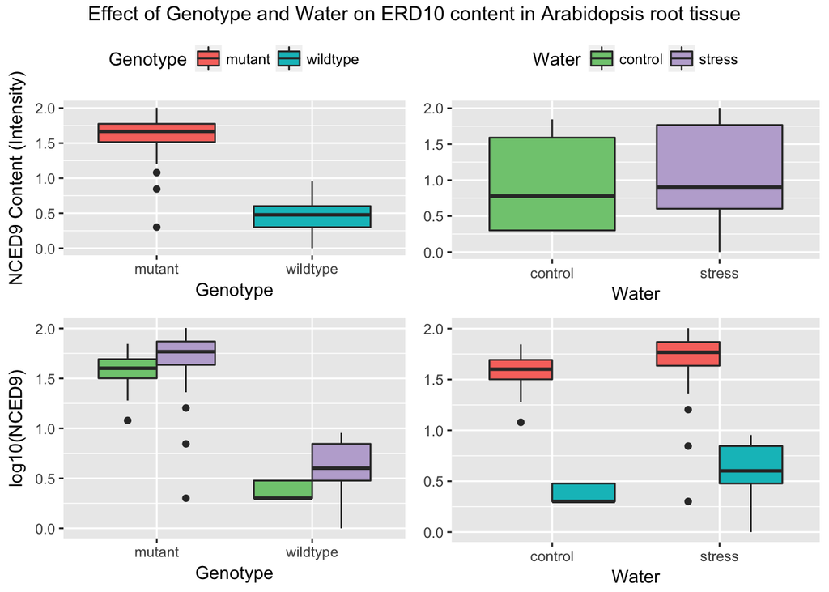

```r
wNCED9 <- ggplot(plant_data)+
  geom_boxplot(aes(Genotype, log10(NCED9), fill = Genotype)) +
  ylab('NCED9 Content (Intensity)')+
  theme(legend.position = 'top')

gNCED9 <- ggplot(plant_data)+
  geom_boxplot(aes(Water, log10(NCED9), fill = Water))+
  theme(legend.position = 'top', axis.title.y = element_blank())+
  scale_fill_brewer(palette = 'Accent')

iNCED9 <- ggplot(plant_data)+
  geom_boxplot(aes(Genotype, log10(NCED9), fill = Water))+
  theme(legend.position = 'none')+
   scale_fill_brewer(palette = 'Accent')

inNCED9 <- ggplot(plant_data)+
  geom_boxplot(aes(Water, log10(NCED9), fill = Genotype))+
  theme(legend.position = 'none', axis.title.y = element_blank())

ggarrange(wNCED9,gNCED9,iNCED9,inNCED9) %>%
  annotate_figure(top = 'Effect of Genotype and Water on ERD10 content in Arabidopsis root tissue')
```

### SRK2D

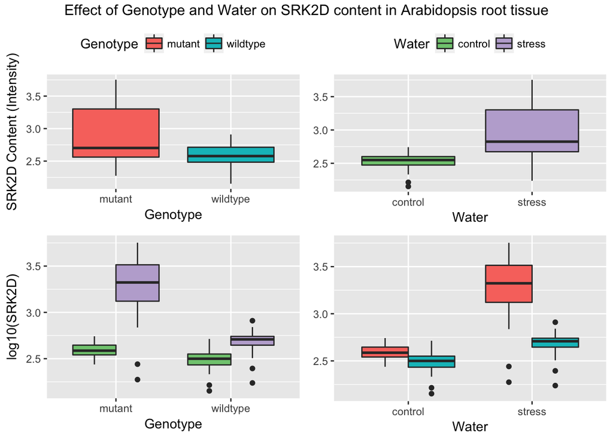

```r
wSRK2D <- ggplot(plant_data)+
  geom_boxplot(aes(Genotype, log10(SRK2D), fill = Genotype)) +
  ylab('SRK2D Content (Intensity)')+
  theme(legend.position = 'top')

gSRK2D <- ggplot(plant_data)+
  geom_boxplot(aes(Water, log10(SRK2D), fill = Water))+
  theme(legend.position = 'top', axis.title.y = element_blank())+
  scale_fill_brewer(palette = 'Accent')

iSRK2D <- ggplot(plant_data)+
  geom_boxplot(aes(Genotype, log10(SRK2D), fill = Water))+
  theme(legend.position = 'none')+
   scale_fill_brewer(palette = 'Accent')

inSRK2D <- ggplot(plant_data)+
  geom_boxplot(aes(Water, log10(SRK2D), fill = Genotype))+
  theme(legend.position = 'none', axis.title.y = element_blank())

ggarrange(wSRK2D,gSRK2D,iSRK2D,inSRK2D) %>%
  annotate_figure(top = 'Effect of Genotype and Water on SRK2D content in Arabidopsis root tissue')
```

The two factors in this experiment (Genotype and Water) are both fixed factors. For the analysis effect of each of the factors on protein content, a Fixed-Factor Factorial ANOVA will be performed for each protein response variable. It is clear form exploratory data analysis that there may be some interactions of the factors.

For each protein response variable (ERD10, SRK2D and SRK2D), the null hypothesis that there is no effect of either fixed factor on the protein in question will be tested.

## Two-Factor Factorial ANOVA

### ERD10

```r
# calculate the anova
ERD10_aov <- aov(ERD10 ~ Genotype + Water + Genotype * Water, plant_data)

# calculate anova table for each effect, and the interaction
anova(ERD10_aov)
```

```
## Analysis of Variance Table
##
## Response: ERD10
##                Df  Sum Sq Mean Sq F value    Pr(>F)
## Genotype        1    4234    4234  0.1184   0.73170
## Water           1  243763  243763  6.8179   0.01087 *
## Genotype:Water  1 1452066 1452066 40.6133 1.299e-08 ***
## Residuals      76 2717263   35753
## ---
## Signif. codes:  0 '***' 0.001 '**' 0.01 '*' 0.05 '.' 0.1 ' ' 1
```

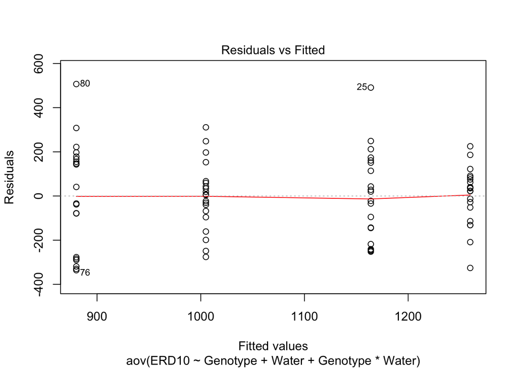

```r
# test the assumption of unequal variance
plot(ERD10_aov, which = 1)
```

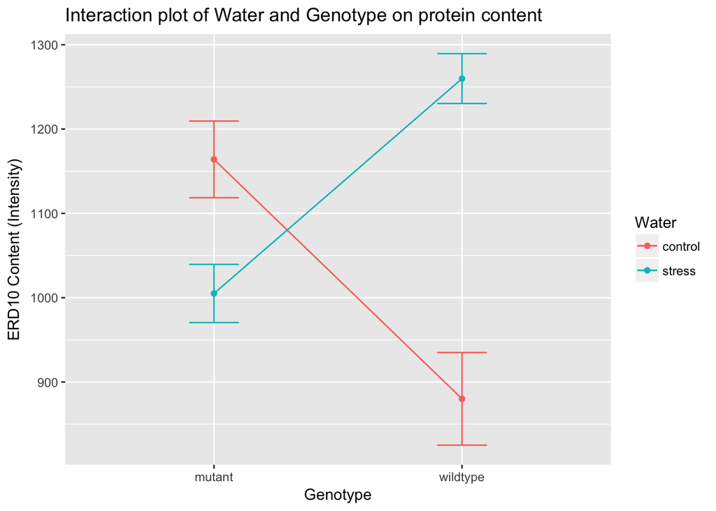

```r
plant_data %>%
  select(Genotype, Water, ERD10) %>%
  group_by(Genotype, Water) %>%
  summarise(mean = mean(ERD10),
            sem = (sd(ERD10))/sqrt((length(ERD10)))) -> ERD10_sum

# setbars
bars = aes(ymin=mean-sem, ymax=mean+sem)

# summarize with an interaction plot
ggplot(data = ERD10_sum, aes(Genotype, mean, color = Water, group = Water))+
  stat_summary(fun.y = mean, geom = 'point') +
  stat_summary(fun.y = mean, geom = 'line') +
  geom_errorbar(bars, width = 0.2)+
  ylab('ERD10 Content (Intensity)') +
  ggtitle('Interaction plot of Water and Genotype on protein content')
```

There is a significant interaction of Water (F<sub>1,76</sub> = 6.8, *p* < 0.05), and the interaction of water and genotype (F<sub>1,76</sub> = 40.6, *p* < 0.001) on the content of ERD10 in Arabidopsis root tissues.

### SRK2D

```r
# calculate the anova
SRK2D_aov <- aov(SRK2D ~ Genotype + Water + Genotype * Water, plant_data)

# calculate anova table for each effect, and the interaction
anova(SRK2D_aov)
```

```
## Analysis of Variance Table
##
## Response: SRK2D
##                Df   Sum Sq  Mean Sq F value    Pr(>F)
## Genotype        1 19634684 19634684  33.406 1.560e-07 ***
## Water           1 23800165 23800165  40.493 1.353e-08 ***
## Genotype:Water  1 16593865 16593865  28.232 1.039e-06 ***
## Residuals      76 44669690   587759
## ---
## Signif. codes:  0 '***' 0.001 '**' 0.01 '*' 0.05 '.' 0.1 ' ' 1
```

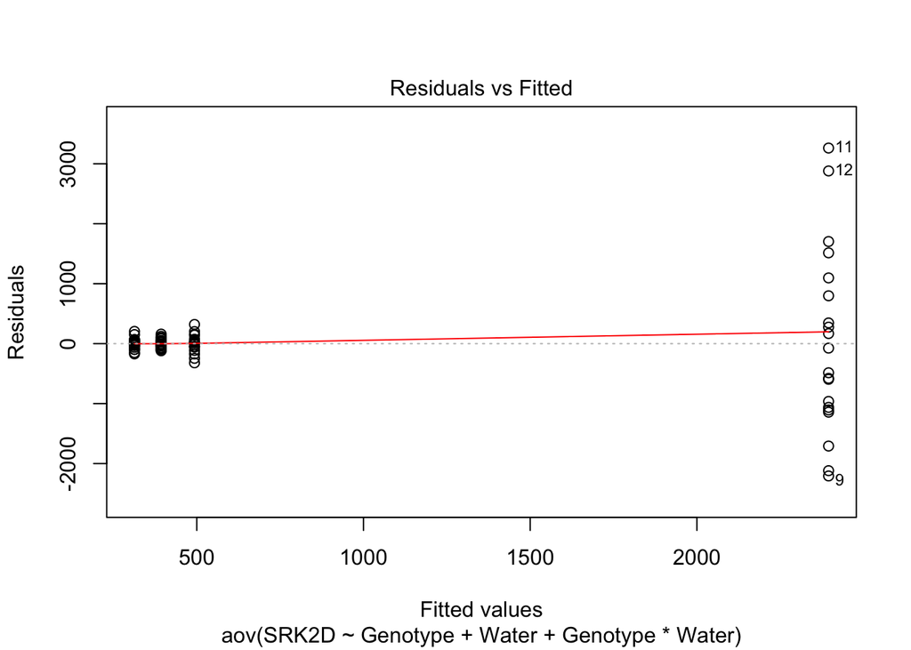

```r
# test the assumption of unequal variance
plot(SRK2D_aov, which = 1)
```

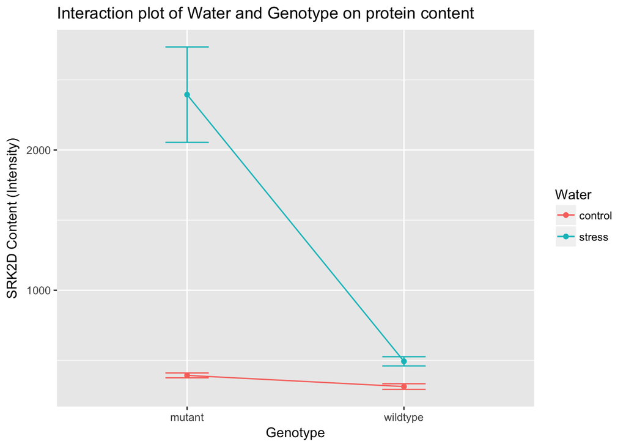

```r
plant_data %>%
  select(Genotype, Water, SRK2D) %>%
  group_by(Genotype, Water) %>%
  summarise(mean = mean(SRK2D),
            sem = (sd(SRK2D))/sqrt((length(SRK2D)))) -> SRK2D_sum

# setbars
bars = aes(ymin=mean-sem, ymax=mean+sem)

# summarize with an interaction plot
ggplot(data = SRK2D_sum, aes(Genotype, mean, color = Water, group = Water))+
  stat_summary(fun.y = mean, geom = 'point') +
  stat_summary(fun.y = mean, geom = 'line') +
  geom_errorbar(bars, width = 0.2)+
  ylab('SRK2D Content (Intensity)') +
  ggtitle('Interaction plot of Water and Genotype on protein content')
```

There is a significant effect of genotype (F<sub>1,76</sub> = 33.4, *p* < 0.001), water (F<sub>1,76</sub> = 40.5, *p* < 0.001), and the inteaction of genotype and water (F<sub>1,76</sub> = 28.2, *p* < 0.001) on the content of SRK2D in Arabidopsis root tissues.

### NCED9

```r
# calculate the anova
NCED9_aov <- aov(NCED9 ~ Genotype + Water + Genotype * Water, plant_data)

# calculate anova table for each effect, and the interaction
anova(NCED9_aov)
```

```
## Analysis of Variance Table
##
## Response: NCED9
##                Df Sum Sq Mean Sq  F value  Pr(>F)
## Genotype        1  37889   37889 159.6168 < 2e-16 ***
## Water           1   1593    1593   6.7115 0.01148 *
## Genotype:Water  1    932     932   3.9247 0.05120 .
## Residuals      76  18040     237
## ---
## Signif. codes:  0 '***' 0.001 '**' 0.01 '*' 0.05 '.' 0.1 ' ' 1
```

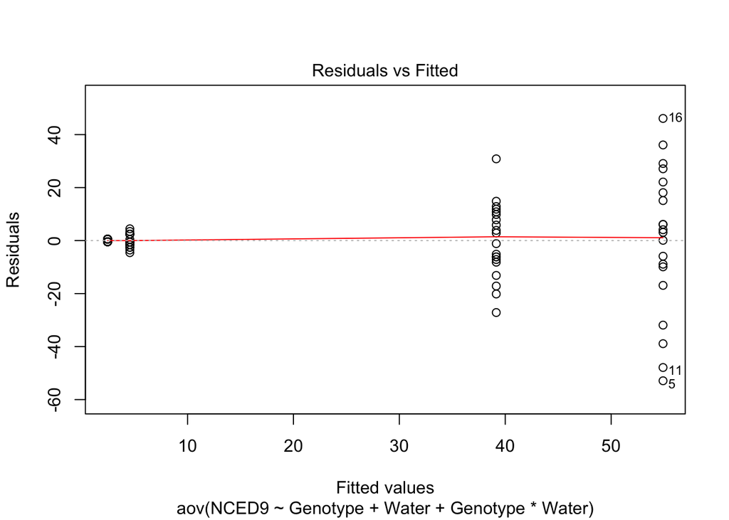

```r
# test the assumption of unequal variance
plot(NCED9_aov, which = 1)
```

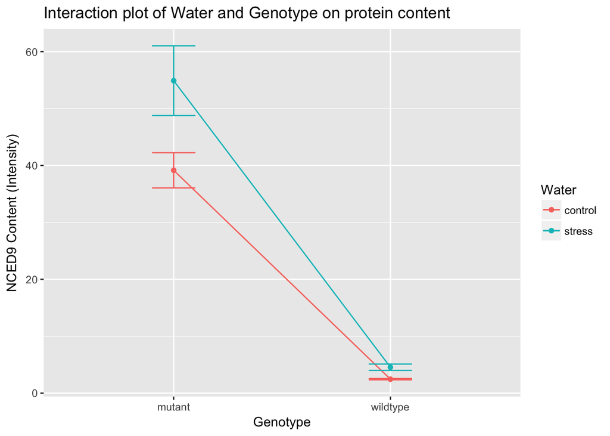

```r
plant_data %>%
  select(Genotype, Water, NCED9) %>%
  group_by(Genotype, Water) %>%
  summarise(mean = mean(NCED9),
            sem = (sd(NCED9))/sqrt((length(NCED9)))) -> NCED9_sum

# setbars
bars = aes(ymin=mean-sem, ymax=mean+sem)

# summarize with an interaction plot
ggplot(data = NCED9_sum, aes(Genotype, mean, color = Water, group = Water))+
  stat_summary(fun.y = mean, geom = 'point') +
  stat_summary(fun.y = mean, geom = 'line') +
  geom_errorbar(bars, width = 0.2)+
  ylab('NCED9 Content (Intensity)') +
  ggtitle('Interaction plot of Water and Genotype on protein content')
```

There is a significant effect of genotype (F<sub>1,76</sub> = 159.6, *p* < 0.001), and water (F<sub>1,76</sub> = 6.7, *p* < 0.05) on the content of NCED9 in Arabidopsis root tissues; a mild, non-significant effect of the ineraction of genotype and water was found (F<sub>1,76</sub> = 3.9, *p* < 0.1)